# 市场观察

2017/05/05

## A、指数估值

### (a1)动态市盈率、市净率

核心指数成分股近18个月的动态市盈率及动态市净率中位数走势如下图所示：

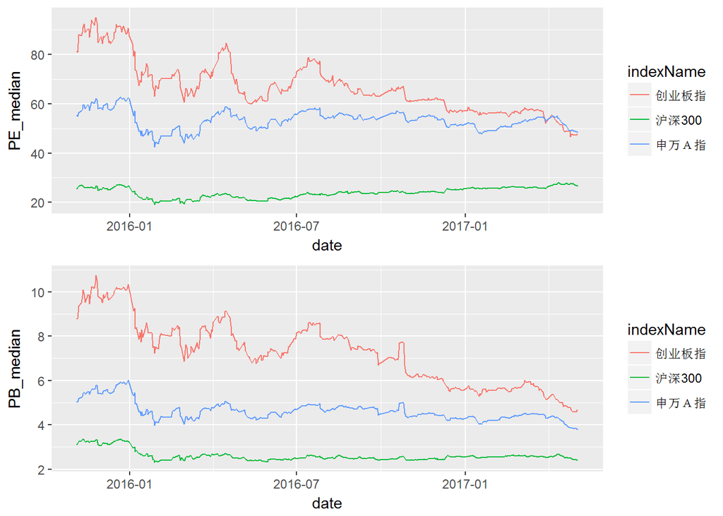

### (a2)动态市盈率、市净率百分位

核心指数近18个月的动态市盈率百分位及动态市净率百分位走势如下图所示：

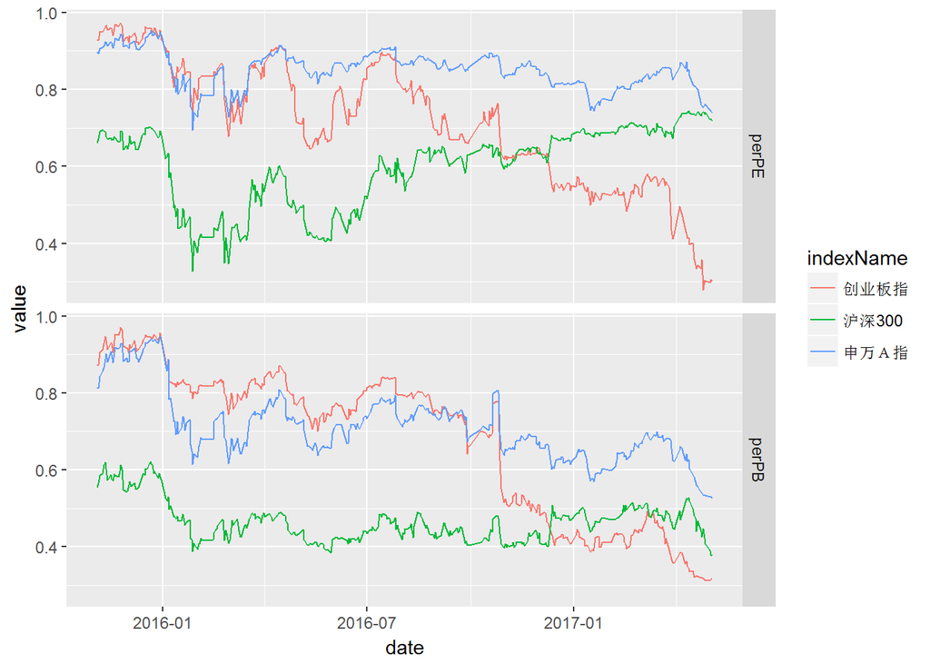

### (a3)指数估值概览

| 指数代码 | 指数简称 | 日期 | 动态市盈率 | 市盈率百分位 | 动态市净率 | 市净率百分位 |
| --- | --- | --- | --- | --- | --- | --- |
| EI801003 | 申万Ａ指 | 2017-05-04 | 48.3 | 74% | 3.8 | 53% |
| EI399959 | 军工指数 | 2017-05-04 | 88.5 | 71% | 4.2 | 51% |
| EI000979 | 大宗商品 | 2017-05-04 | 32.1 | 59% | 2.6 | 52% |
| EI399330 | 深证100 | 2017-05-04 | 32.2 | 65% | 3.5 | 45% |
| EI000300 | 沪深300 | 2017-05-04 | 26.6 | 72% | 2.4 | 38% |
| EI000819 | 有色金属 | 2017-05-04 | 52.4 | 68% | 2.9 | 24% |
| EI399005 | 中小板指P | 2017-05-04 | 39.3 | 57% | 4.3 | 35% |
| EI000905 | 中证500 | 2017-05-04 | 36.5 | 50% | 2.9 | 32% |
| EI000016 | 上证50 | 2017-05-04 | 18.5 | 66% | 1.5 | 7% |
| EI000934 | 中证金融 | 2017-05-04 | 18.5 | 57% | 1.7 | 11% |
| EI000998 | 中证TMT | 2017-05-04 | 41.2 | 37% | 3.7 | 30% |
| EI399006 | 创业板指 | 2017-05-04 | 47.4 | 30% | 4.6 | 32% |
| EI000827 | 中证环保 | 2017-05-04 | 37.0 | 37% | 2.8 | 16% |
| EI000922 | 中证红利 | 2017-05-04 | 15.4 | 23% | 1.6 | 14% |
| EI000932 | 中证消费 | 2017-05-04 | 29.1 | 25% | 3.4 | 5% |
| EI000933 | 中证医药 | 2017-05-04 | 32.6 | 19% | 3.6 | 1% |

### (a4)另类估值

我国10年期国债收益率、金银比价、金油比价，2000年以来的历史百分位如下图所示：

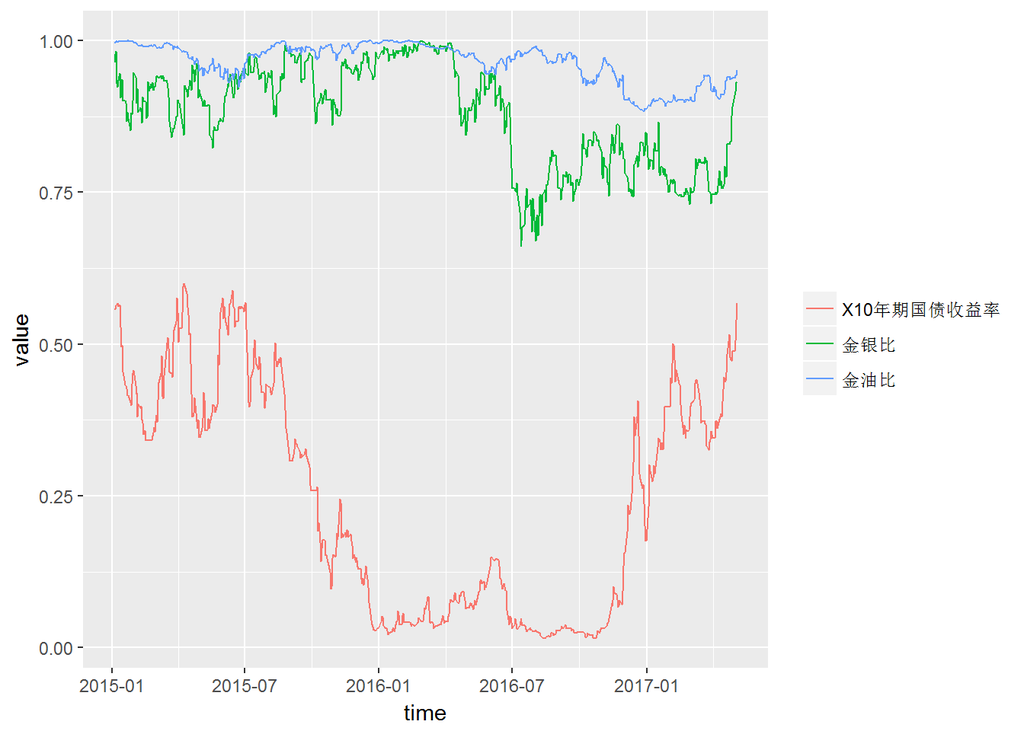

## B、基差

### (b1)基差走势

三大股指期货合约基差走势如下图，其中当月合约和次月合约年化基差百分比波动较大，仅展示合约基差百分比，当季合约和次季合约展示基差年化百分比：

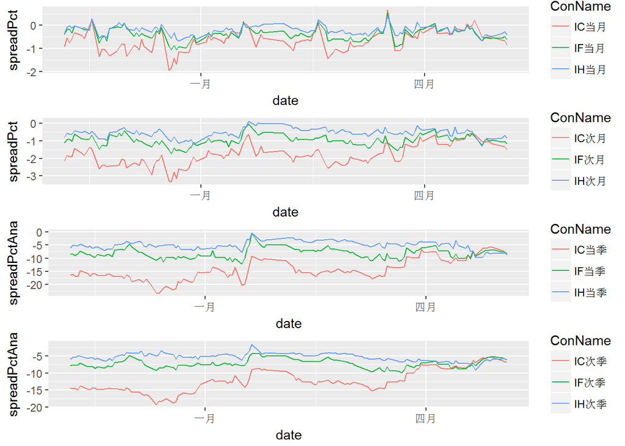

### (b2)基差概况

三大股指期货连续合约基差概况如下表，近月合约临近到期日，年化基差百分比数据波动较大：

| 日期 | 合约代码 | 合约收盘价 | 指数收盘价 | 基差 | 基差百分比 | 年化基差百分比 |
| --- | --- | --- | --- | --- | --- | --- |
| 2017-05-04 | IC1705 | 6123.6 | 6176.3 | -52.7 | -0.9% | -23.0% |
| 2017-05-04 | IC1706 | 6083.8 | 6176.3 | -92.5 | -1.5% | -13.4% |
| 2017-05-04 | IC1709 | 5991.0 | 6176.3 | -185.3 | -3.0% | -8.4% |
| 2017-05-04 | IC1712 | 5923.0 | 6176.3 | -253.3 | -4.1% | -6.7% |
| 2017-05-04 | IF1705 | 3383.4 | 3404.4 | -21.0 | -0.6% | -16.1% |
| 2017-05-04 | IF1706 | 3364.6 | 3404.4 | -39.8 | -1.2% | -10.4% |
| 2017-05-04 | IF1709 | 3298.4 | 3404.4 | -106.0 | -3.1% | -8.7% |
| 2017-05-04 | IF1712 | 3279.0 | 3404.4 | -125.4 | -3.7% | -6.0% |
| 2017-05-04 | IH1705 | 2316.2 | 2325.4 | -9.2 | -0.4% | -10.1% |
| 2017-05-04 | IH1706 | 2305.4 | 2325.4 | -20.0 | -0.9% | -7.6% |
| 2017-05-04 | IH1709 | 2256.2 | 2325.4 | -69.2 | -3.0% | -8.3% |
| 2017-05-04 | IH1712 | 2240.0 | 2325.4 | -85.4 | -3.7% | -6.0% |

## C、套利和事件

### (c1)复牌股票套利

近两天复牌股票套利情况如下表：

[1] “No valuation adjustment!”

[1] “No Arbitrage!”

### (c2)定增基金(provided by han.qian)

定增基金数据如下表，明细数据参见钱瀚的模板。

| 代码 | 名称 | 到期日期 | 最新净值 | 昨日收盘价 | 折溢价率 | 整体隐含折价率 | 大盘下跌0.1净值变化 |
| --- | --- | --- | --- | --- | --- | --- | --- |
| 168101.OF | 九泰锐智 | 20200814 | 1.19 | 1.04 | -11.9% | 3.9% | -9.7% |
| 168102.OF | 九泰锐富 | 20210204 | 1.02 | 0.87 | -15.1% | 3.1% | -5.3% |
| 501015.OF | 财通升级 | 20170908 | 1.02 | 0.99 | -2.6% | 1.9% | -8.9% |
| 160518.OF | 博时睿远 | 20171016 | 0.97 | 0.93 | -4.5% | 1.2% | -6.4% |

定增基金近期的净值走势如下图：

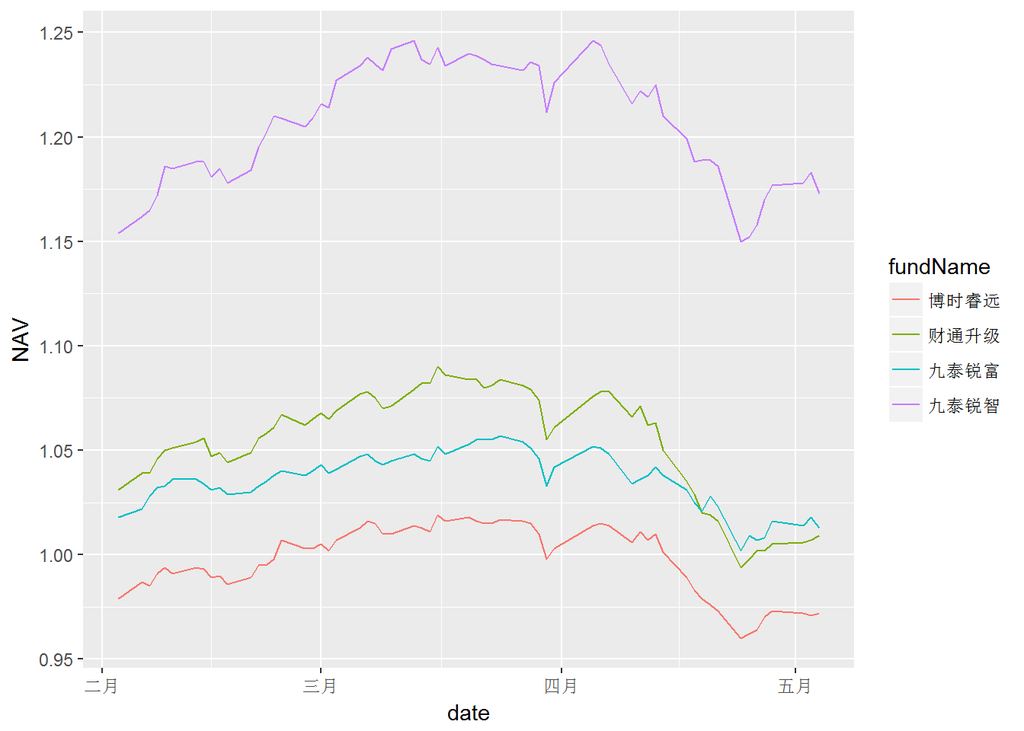

定增基金近期的折溢价率百分比走势如下图：

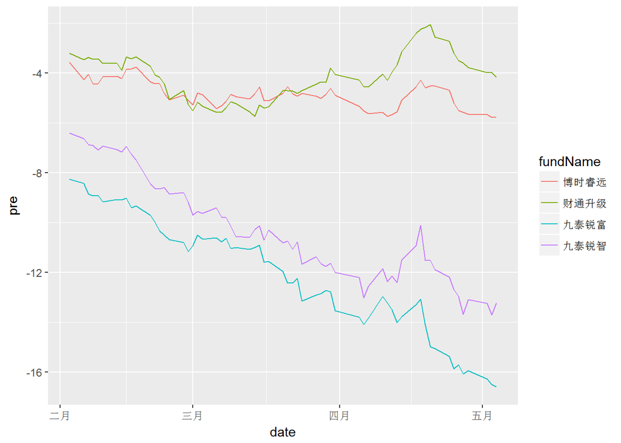

### (c3)定增解禁(provided by han.qian)

近十天定增解禁的股票情况如下表。

| 股票代码 | 股票简称 | 起始跟踪日 | 解禁日 | 解禁百分比 | 区间涨跌幅 | 所属行业指数 | 行业指数涨跌幅 |
| --- | --- | --- | --- | --- | --- | --- | --- |
| EQ300269 | 联建光电 | 2017-04-19 | 2017-05-04 | 7% | -4.1% | 申万电子 | 0.5% |
| EQ600497 | 驰宏锌锗 | 2017-04-19 | 2017-05-04 | 15% | -7.3% | 申万有色金属 | -6.6% |
| EQ000816 | 智慧农业 | 2017-04-20 | 2017-05-05 | 23% | -9.1% | 申万机械设备 | -2.2% |
| EQ002607 | 亚夏汽车 | 2017-04-20 | 2017-05-05 | 28% | -0.8% | 申万汽车 | -2.1% |
| EQ300159 | 新研股份 | 2017-04-20 | 2017-05-05 | 5% | 4.7% | 申万机械设备 | -2.2% |
| EQ000887 | 中鼎股份 | 2017-04-21 | 2017-05-08 | 8% | -2.7% | 申万汽车 | -2.3% |
| EQ002335 | 科华恒盛 | 2017-04-21 | 2017-05-08 | 19% | -4.1% | 申万电气设备 | -2.9% |
| EQ002654 | 万润科技 | 2017-04-21 | 2017-05-08 | 7% | -4.4% | 申万电子 | 0.6% |
| EQ002425 | 凯撒文化 | 2017-04-24 | 2017-05-09 | 6% | -1.7% | 申万纺织服装 | -1.2% |
| EQ300266 | 兴源环境 | 2017-04-24 | 2017-05-09 | 8% | 0.0% | 申万机械设备 | -1.2% |
| EQ300343 | 联创互联 | 2017-04-24 | 2017-05-09 | 20% | -2.5% | 申万传媒 | -0.8% |
| EQ600565 | 迪马股份 | 2017-04-24 | 2017-05-09 | 59% | -9.9% | 申万房地产 | -3.5% |
| EQ300279 | 和晶科技 | 2017-04-25 | 2017-05-10 | 10% | 3.5% | 申万电子 | 3.0% |
| EQ300287 | 飞 利 信 | 2017-04-25 | 2017-05-10 | 18% | 4.4% | 申万计算机 | 1.0% |
| EQ601222 | 林洋能源 | 2017-04-25 | 2017-05-10 | 22% | 3.2% | 申万电气设备 | 0.7% |
| EQ300433 | 蓝思科技 | 2017-04-26 | 2017-05-11 | 75% | 10.4% | 申万电子 | 2.2% |
| EQ603885 | 吉祥航空 | 2017-04-26 | 2017-05-11 | 69% | -1.2% | 申万交通运输 | 0.9% |
| EQ002092 | 中泰化学 | 2017-04-27 | 2017-05-12 | 22% | -2.6% | 申万化工 | 0.8% |
| EQ603601 | 再升科技 | 2017-04-27 | 2017-05-14 | 36% | 0.0% | 申万化工 | 0.8% |
| EQ002004 | 华邦健康 | 2017-04-28 | 2017-05-15 | 8% | 1.6% | 申万化工 | 0.1% |
| EQ600770 | 综艺股份 | 2017-04-28 | 2017-05-15 | 18% | -0.1% | 申万综合 | -0.5% |
| EQ002174 | 游族网络 | 2017-05-02 | 2017-05-16 | 173% | -3.2% | 申万传媒 | -0.9% |
| EQ002390 | 信邦制药 | 2017-05-02 | 2017-05-16 | 8% | 0.0% | 申万医药生物 | -0.6% |
| EQ000420 | 吉林化纤 | 2017-05-03 | 2017-05-17 | 70% | -2.2% | 申万化工 | -0.7% |
| EQ300059 | 东方财富 | 2017-05-03 | 2017-05-17 | 6% | -2.3% | 申万传媒 | -0.6% |
| EQ300166 | 东方国信 | 2017-05-03 | 2017-05-17 | 14% | 1.6% | 申万计算机 | 0.4% |
| EQ002239 | 奥 特 佳 | 2017-05-05 | 2017-05-19 | 11% | 0.0% | 申万汽车 | 0.0% |
| EQ002670 | 国盛金控 | 2017-05-05 | 2017-05-19 | 109% | 0.0% | 申万家用电器 | 0.0% |
| EQ300301 | 长方集团 | 2017-05-05 | 2017-05-20 | 17% | 0.0% | 申万电子 | 0.0% |
| EQ300410 | 正业科技 | 2017-05-05 | 2017-05-19 | 34% | 0.0% | 申万电子 | 0.0% |

### (c4)中小板业绩预增预测(provided by han.qian)

中小板规定正式财务报告发布的同时需要发布新一期的业绩预报，比如年报中会包含一季报预告的情况。我们假设公司的盈利状况有动量效应，年报预增的公司一季度也会预增，在正式财务报告发布前20个交易日开始埋伏，然后等正式报告发布日卖出。具体研究参见钱瀚前期的研究。需要注意的是这里的收益率仅做展示，仅仅是每日全部入选股票的平均收益率，并没有做成一个事件组合。

[figure not shown]

历年收益统计如下表所示。

|  | 业绩预增 | 中小板指 |
| --- | --- | --- |
| 2013-01-04 ~ 2013-12-31 | 26.4% | 17.5% |
| 2014-01-02 ~ 2014-12-31 | 20.7% | 9.7% |
| 2015-01-05 ~ 2015-12-31 | 78.5% | 53.7% |
| 2016-01-04 ~ 2016-12-30 | 22.3% | -22.9% |
| 2017-01-03 ~ 2017-04-28 | -1.3% | 2.6% |
| Cumulative Return | 228.9% | 56.7% |
| Annualized Return | 46.3% | 11.0% |